# Relative fitness in a field setting - Figure 4 (Evolution MS)

Here we need to subset the data to only look at Biomass when CensorReproduction = 1, so that all Biomass data is for reproductive individuals only.

```r
reproduction_mydata<-subset(mydata,CensorReproduction%in%c('1')) #Here I am only looking at the Biomass data where the CensorReproduction = 1
repro_mydata<-na.omit(reproduction_mydata)
```

##Histograms ###Original data The original data is skewed and fails the Shapiro-Wilk normality test, so we should consider a log transformation.

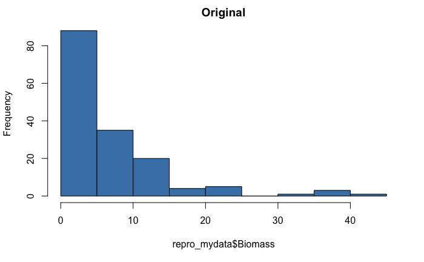

```r
#All data
hist(repro_mydata$Biomass,col='steelblue',
     main='Original') #Original data is skewed, let's test for normality and consider log transforming the data
```

```r
shapiro.test(repro_mydata$Biomass) #fails the Shapiro-Wilk normality test
```

```
    Shapiro-Wilk normality test

data:  repro_mydata$Biomass
W = 0.7266, p-value = 9.233e-16
```

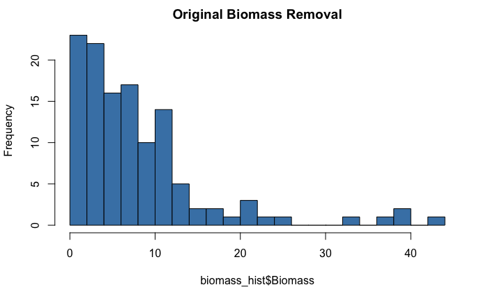

```r
#Biomass Removal data
biomass_hist<-repro_mydata %>%
  select(Biomass,Treatment) %>%
  filter(Treatment =="Biomass Removal")
hist(biomass_hist$Biomass,breaks=20,col='steelblue',main='Original Biomass Removal')
```

###Log transform data (https://www.statology.org/transform-data-in-r/) Log transformed data has a better distribution than the original data (although it still fails the Shapiro-Wilk normality test) so we will use the log transformed data with our models.

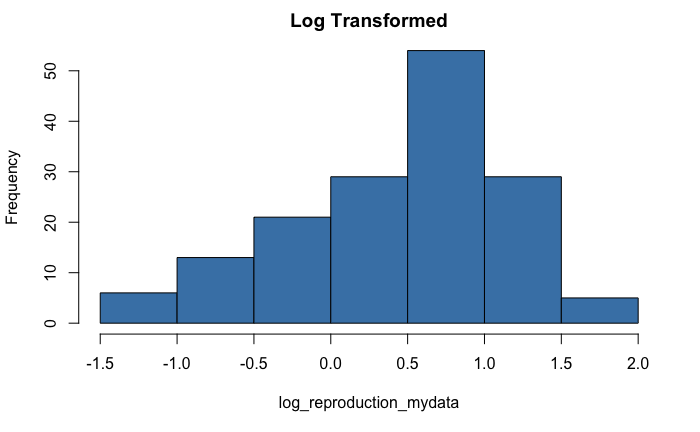

```r
log_reproduction_mydata<-log10(repro_mydata$Biomass)
hist(log_reproduction_mydata,col='steelblue',
     main='Log Transformed') #Log transformed data, this looks better than the original distribution
```

```r
shapiro.test(log_reproduction_mydata) #but it fails this test
```

```
    Shapiro-Wilk normality test

data:  log_reproduction_mydata
W = 0.94952, p-value = 1.959e-05
```

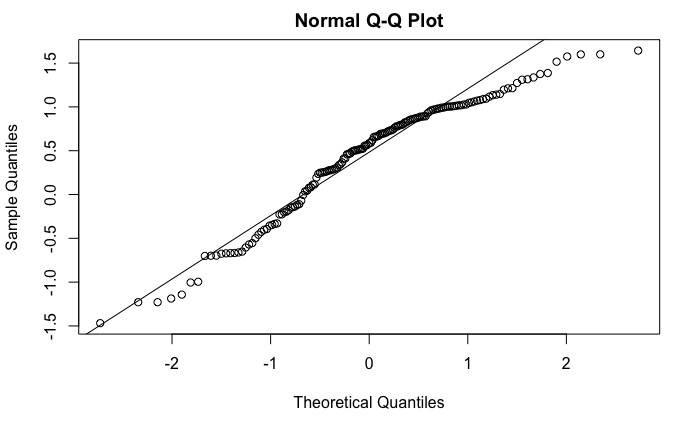

```r
qqnorm(log_reproduction_mydata) #qqplot
qqline(log_reproduction_mydata) #add the line... kinda wobbly around the ends
```

###Square root transform data Nope, not square root

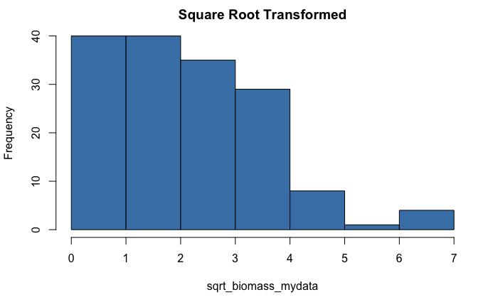

```r
sqrt_biomass_mydata<-sqrt(repro_mydata$Biomass)
hist(sqrt_biomass_mydata,
     col='steelblue',main='Square Root Transformed') #nope, this does not look better
```

```r
shapiro.test(sqrt_biomass_mydata)
```

```
    Shapiro-Wilk normality test

data:  sqrt_biomass_mydata
W = 0.93708, p-value = 1.987e-06
```

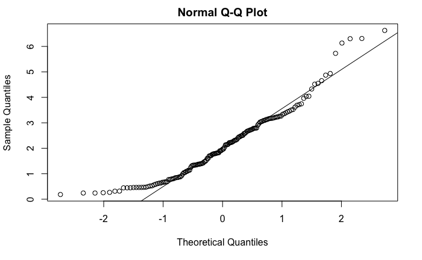

```r
qqnorm(sqrt_biomass_mydata) #qqplot
qqline(sqrt_biomass_mydata) #add the line
```

###Poisson distribution Poisson is actually not a good fit because the growth rate is not an integer (has decimals), which poisson cannot deal with. Maybe I’ll try gamma?

```r
library(MASS)
MASS::fitdistr((repro_mydata$Biomass*1000),
               "Poisson")
```

```
     lambda
  6420.076433
 (   6.394701)
```

```
[1]  57 108
```

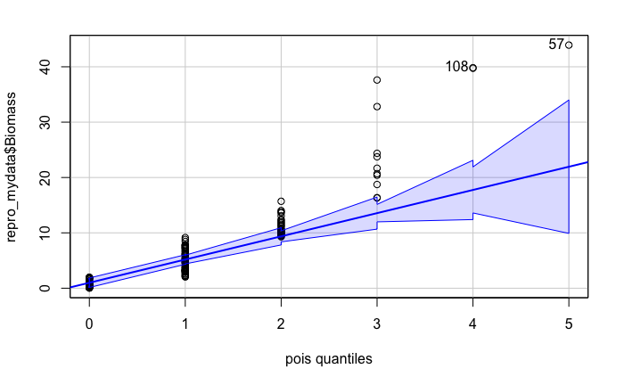

```r
qqPlot(repro_mydata$Biomass,
       distribution="pois",
       lambda=1)
```

###Gamma distribution Maybe?

```
[1]  57 108
```

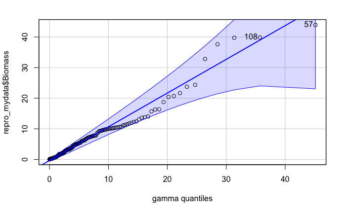

```r
gamma<-fitdistr(repro_mydata$Biomass,
                "gamma")
qqp(repro_mydata$Biomass,
    "gamma",
    shape=gamma$estimate[[1]],
    rate=gamma$estimate[[2]])
```

##Models Julia recommends the log and gamma… then use DHARMa to test the dispersion of each models

```r
summary(fullmodel1) #but this runs fine
```

[output not shown]

```
Linear mixed model fit by REML. t-tests use Satterthwaite's method ['lmerModLmerTest']
Formula: log(Biomass) ~ Habitat * Treatment + (1 | Block)
   Data: repro_mydata

REML criterion at convergence: 414.2

Scaled residuals:
    Min      1Q  Median      3Q     Max
-3.2800 -0.5732  0.0033  0.6569  2.4381

Random effects:
 Groups   Name        Variance Std.Dev.
 Block    (Intercept) 0.2717   0.5212
 Residual             0.7152   0.8457
Number of obs: 157, groups:  Block, 10

Fixed effects:
                                          Estimate Std. Error       df t value Pr(>|t|)
(Intercept)                                -1.4978     0.2579  35.5278  -5.808 1.31e-06 ***
HabitatVegetated                            0.5960     0.2915 145.3124   2.045   0.0427 *
TreatmentBiomass Removal                    3.1903     0.2271 145.9753  14.049  < 2e-16 ***
HabitatVegetated:TreatmentBiomass Removal  -0.6511     0.3284 144.7802  -1.982   0.0493 *
---
Signif. codes:  0 ‘***’ 0.001 ‘**’ 0.01 ‘*’ 0.05 ‘.’ 0.1 ‘ ’ 1

Correlation of Fixed Effects:
            (Intr) HbttVg TrtmBR
HabittVgttd -0.512
TrtmntBmssR -0.675  0.578
HbttVgt:TBR  0.455 -0.884 -0.671
```

###Full Model 2 - glmm

```r
fullmodel2<-glmmTMB(Biomass~
                             Habitat*Treatment+
                             (1|Site)+
                             (1|Block),
                           family=Gamma(link="log"),
                           data=repro_mydata)
summary(fullmodel2)
```

```
 Family: Gamma  ( log )
Formula:          Biomass ~ Habitat * Treatment + (1 | Site) + (1 | Block)
Data: repro_mydata

     AIC      BIC   logLik deviance df.resid
   738.8    760.2   -362.4    724.8      150

Random effects:

Conditional model:
 Groups Name        Variance  Std.Dev.
 Site   (Intercept) 1.505e-09 3.879e-05
 Block  (Intercept) 1.794e-01 4.236e-01
Number of obs: 157, groups:  Site, 8; Block, 10

Dispersion estimate for Gamma family (sigma^2): 0.583

Conditional model:
                                          Estimate Std. Error z value Pr(>|z|)
(Intercept)                                -1.1677     0.2258  -5.171 2.32e-07 ***
HabitatVegetated                            0.6390     0.2636   2.424  0.01536 *
TreatmentBiomass Removal                    3.2082     0.2128  15.074  < 2e-16 ***
HabitatVegetated:TreatmentBiomass Removal  -0.7766     0.2975  -2.610  0.00904 **
---
Signif. codes:  0 ‘***’ 0.001 ‘**’ 0.01 ‘*’ 0.05 ‘.’ 0.1 ‘ ’ 1
```

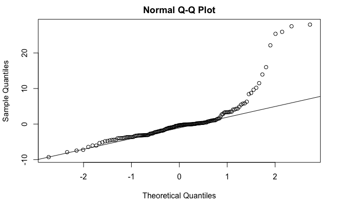

```r
qqnorm(resid(fullmodel2)) #qqplot
qqline(resid(fullmodel2)) #add the line
```

```
    DHARMa nonparametric dispersion test via sd of residuals fitted vs. simulated

data:  simulationOutput
dispersion = 1.2625, p-value = 0.48
alternative hypothesis: two.sided
```

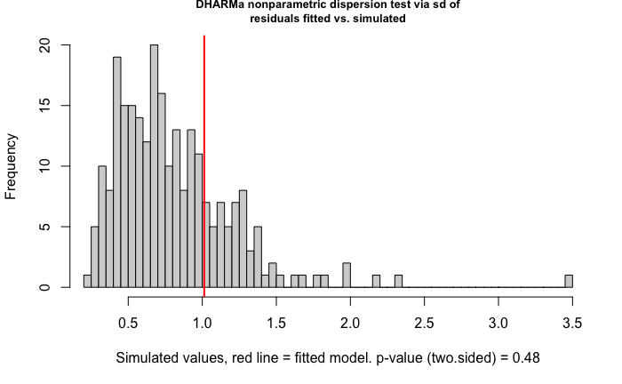

```r
testDispersion(fullmodel2) #red line should be in the middle of the distribution
```

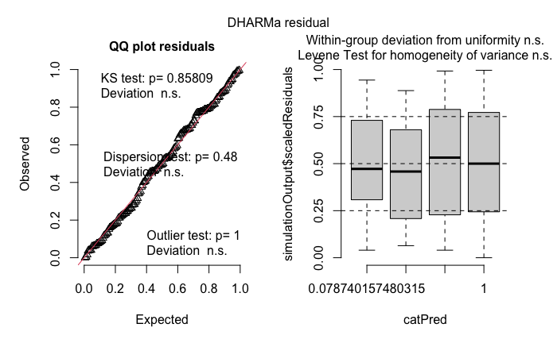

```r
myDHARMagraph2<-simulateResiduals(fullmodel2) #making a graph using DHARMa package, also testing for heteroscedasticity, https://cran.r-project.org/web/packages/DHARMa/vignettes/DHARMa.html#heteroscedasticity
plot(myDHARMagraph2) #plotting graph. Looks good, but check the outliers to make sure they are real.
```

###Best Model

```r
fullmodel1
```

```
Linear mixed model fit by REML ['lmerModLmerTest']
Formula: log(Biomass) ~ Habitat * Treatment + (1 | Block)
   Data: repro_mydata
REML criterion at convergence: 414.1645
Random effects:
 Groups   Name        Std.Dev.
 Block    (Intercept) 0.5212
 Residual             0.8457
Number of obs: 157, groups:  Block, 10
Fixed Effects:
                              (Intercept)                           HabitatVegetated
                                  -1.4978                                     0.5960
                 TreatmentBiomass Removal  HabitatVegetated:TreatmentBiomass Removal
                                   3.1903                                    -0.6511
```

#ggplot - interaction plots Treatment (Biomass Removal and Grassland) on the x-axis, using Roadside and Vegetated data

##Growth Rate x Treatment: Growth

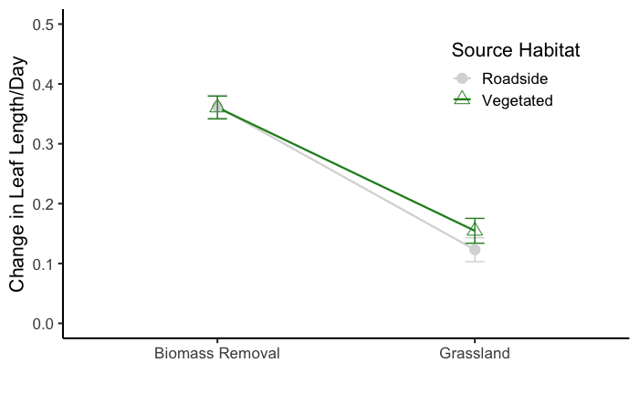

```r
pd<-position_dodge(0)

growth_mydata2<-growth_mydata%>%
  replace_na(list(Growth.Rate=0))%>%
  filter(CensorReproduction==1)%>%
  #filter(Treatment=="Biomass Removal"|Treatment=="Grassland")%>%
  group_by(Treatment,Habitat)%>%
  summarise(Mean=mean(Growth.Rate),
            SD=sd(Growth.Rate),
            N=length(Growth.Rate))%>%
  mutate(SE=SD/sqrt(N))
field_int_rate_grow_gg<-ggplot(growth_mydata2,
                        aes(x=factor(Treatment,levels=c("Biomass Removal","Grassland")),
                            y=Mean,
                            shape=Habitat,
                            group=Habitat,
                            color=Habitat))+
  coord_cartesian(ylim = c(0,0.5))+
  xlab("")+
  theme_bw(base_size=16)+
  theme(panel.border=element_blank(),
        panel.grid.major=element_blank(),
        panel.grid.minor=element_blank(),
        axis.line=element_line(colour="black"),
        axis.title.y=ggtext::element_markdown(),
        legend.position = c(0.8, 0.8))+
 # ggtitle("Growth of Dittrichia graveolens that budded")+
  ylab("*Dittrichia graveolens* \n (Change in Leaf Length/Days)")+
  geom_line(size=0.8,
            position=pd)+
  geom_point(size=4,
             position=pd)+
  scale_shape_manual(values=c(16,2))+
  scale_color_manual(values=c("gray85","forestgreen"))+
  geom_errorbar(width=0.15,
                position=pd,
                aes(ymin=(Mean-SE),
                    ymax=(Mean+SE)))+
  labs(y="Change in Leaf Length/Day",
       color="Source Habitat",
       shape="Source Habitat")
field_int_rate_grow_gg
```

```r
#ggsave(plot=field_int_rate_grow_gg,file="/Users/Miranda/Documents/Education/UC Santa Cruz/Dittrichia/Dittrichia_Analysis/figures/field_int_rate_grow_gg.png",width=25,height=15,units="cm",dpi=800)
```

##Survival to bud X Treatment

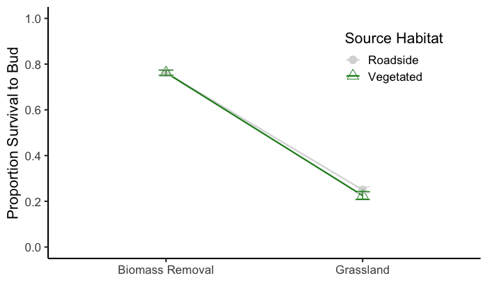

```r
pd<-position_dodge(0)

surv_mydata1<-mydata%>%
  #filter(Treatment=="Biomass Removal"|Treatment=="Grassland")%>%
  group_by(Treatment,Habitat)%>%
  summarise(Mean=mean(PropBudSite),
            SD=sd(PropBudSite),
            N=length(PropBudSite))%>%
  mutate(SE=SD/sqrt(N))
field_int_surv_all_gg<-ggplot(data=surv_mydata1,
                        aes(x=factor(Treatment,levels=c("Biomass Removal","Grassland")),
                            y=Mean,
                            shape=Habitat,
                            group=Habitat,
                            color=Habitat))+
  ylab("Proportion Survival to Bud")+
  coord_cartesian(ylim=c(0,1))+
  xlab("")+
  theme_classic(base_size=16)+
  theme(panel.border=element_blank(),
        panel.grid.major=element_blank(),
        panel.grid.minor=element_blank(),
        axis.line=element_line(colour="black"),
        legend.position = c(0.8, 0.8))+
  scale_y_continuous(name="Proportion Survival to Bud",
                     limits=c(0,1),
                     breaks=c(0.0,0.2,0.4,0.6,0.8,1.0))+
  geom_line(size=0.8,
            position=pd)+
  geom_point(size=4,
             position=pd)+
  scale_shape_manual(values=c(16,2))+
  scale_color_manual(values=c("gray85","forestgreen"))+
  geom_errorbar(width=0.15,
                position=pd,
                aes(ymin=(Mean-SE),
                    ymax=(Mean+SE)))+
  labs(y="Proportion Survival to Bud",
       fill="Source Habitat",
       color="Source Habitat",
       shape="Source Habitat")
field_int_surv_all_gg
```

```r
#ggsave(plot=field_int_surv_all_gg,file="/Users/Miranda/Documents/Education/UC Santa Cruz/Dittrichia/Dittrichia_Analysis/figures/field_int_surv_all_gg.png",width=25,height=15,units="cm",dpi=800)
```

##Biomass x Treatment: Growth

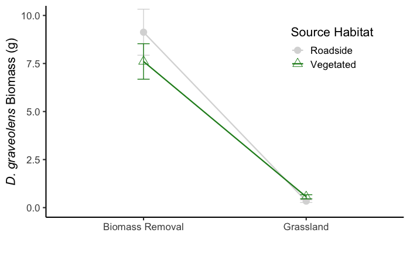

```r
pd<-position_dodge(0)

growth_mydata1<-growth_mydata%>%
  replace_na(list(Biomass=0))%>%
  filter(CensorReproduction==1)%>%
#  filter(Treatment=="Biomass Removal"|Treatment=="Grassland")%>%
  group_by(Treatment,Habitat)%>%
  summarise(Mean=mean(Biomass),
            SD=sd(Biomass),
            N=length(Biomass))%>%
  mutate(SE=SD/sqrt(N))
field_int_bio_grow_gg<-ggplot(growth_mydata1,
                        aes(x=factor(Treatment,levels=c("Biomass Removal","Grassland")),
                            y=Mean,
                            shape=Habitat,
                            group=Habitat,
                            color=Habitat))+
  ylab("Biomass (g)")+
  coord_cartesian(ylim = c(0,10))+
  xlab("")+
  #ggtitle("Biomass of Dittrichia graveolens that budded")+
  theme_bw(base_size=16)+
  theme(panel.border=element_blank(),
        panel.grid.major=element_blank(),
        panel.grid.minor=element_blank(),
        axis.line=element_line(colour="black"),
        axis.title.y=ggtext::element_markdown(),
        legend.position = c(0.8, 0.8))+
  geom_line(size=0.8,
            position=pd)+
  geom_point(size=4,
             position=pd)+
  scale_shape_manual(values=c(16,2))+
  scale_color_manual(values=c("gray85","forestgreen"))+
  geom_errorbar(width=0.15,
                position=pd,
                aes(ymin=(Mean-SE),
                    ymax=(Mean+SE)))+
  labs(y="*D. graveolens* Biomass (g)",
       color="Source Habitat",
       shape="Source Habitat")
field_int_bio_grow_gg
```

```r
#ggsave(plot=field_int_bio_grow_gg,file="/Users/Miranda/Documents/Education/UC Santa Cruz/Dittrichia/Dittrichia_Analysis/figures/field_int_bio_grow_gg.png",width=25,height=15,units="cm",dpi=800)
```

##Figure 4 panel (3 plots)

```r
library(patchwork)

multi_panel_gg<-(field_int_rate_grow_gg+theme(legend.position = c(0.8,0.9)))/
  (field_int_surv_all_gg+theme(legend.position="none"))/
  (field_int_bio_grow_gg+theme(legend.position="none"))+
  plot_annotation(tag_levels=c("A"),
                  tag_suffix=")  ")&
  theme(text=element_text(size=8))
```

[output not shown]